# ML Practical Notebook

## Load Necessary Packages

```r
# Utility
library(dplyr)
# better plots
library(ggplot2)

#logistic regretion libraries
library(e1071)

# Support Vector Libraries
library(nnet)
library(neuralnet)

# random forest
library(randomForest)
```

## Load Data Into Dataframes

loading the larger dataset as training data that will be used to train the ML models prior to being tested using the smaller data set.

```r
# set seed for reproducibility
set.seed(123)

train.data <- read.delim('~/Downloads/assignment_data.tsv', sep = '\t', header = T)
predict.data <- read.delim('~/Downloads/predict_data.tsv', sep = '\t', header = T)
# the predddict dataset has no 'C' value in rs139052738 so we must make sure the levels are the same in both data sets manually
predict.data$rs139052738 <- factor(predict.data$rs139052738, levels = levels(train.data$rs139052738))
```

## Visualise the Data

A few ways I visualize the data to get a grasp of the data included in the files starting by getting a broad view.

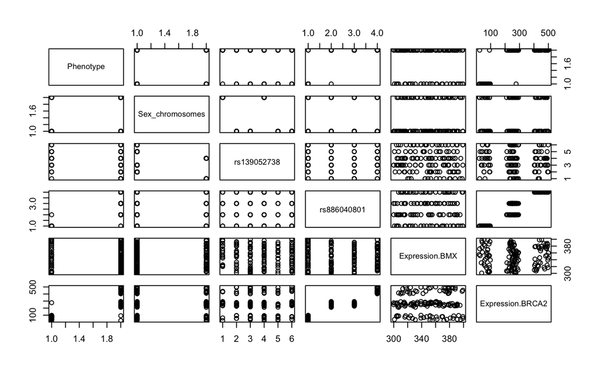

```r
pairs(train.data)
```

and now a few particular plots to explore some relationships between some of the features

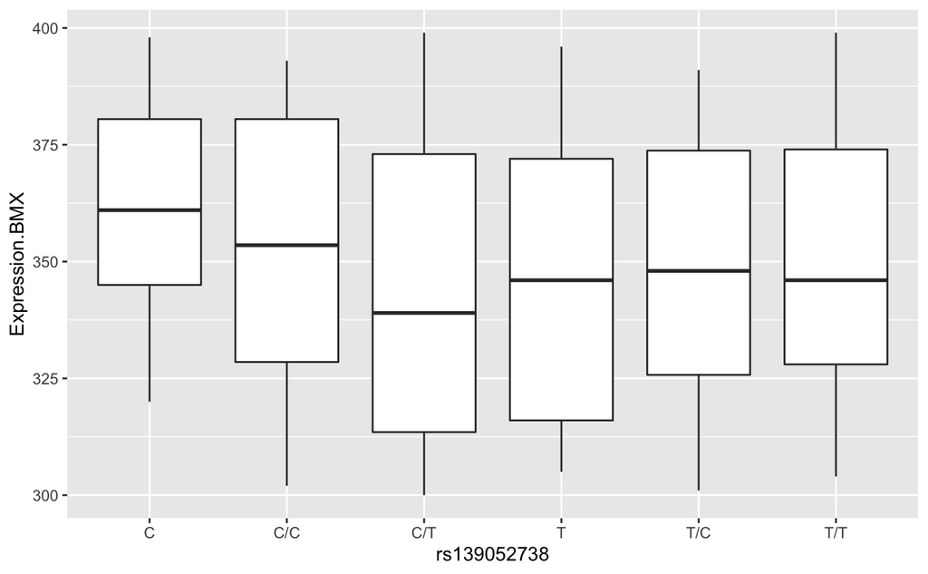

```r
ggplot(train.data)+
  geom_boxplot(aes(rs139052738, Expression.BMX))
```

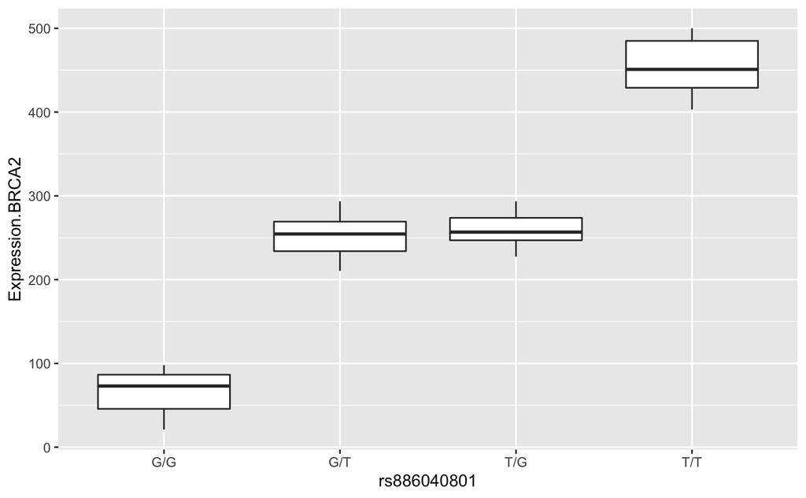

```r
ggplot(train.data)+
  geom_boxplot(aes(rs886040801, Expression.BRCA2))
```

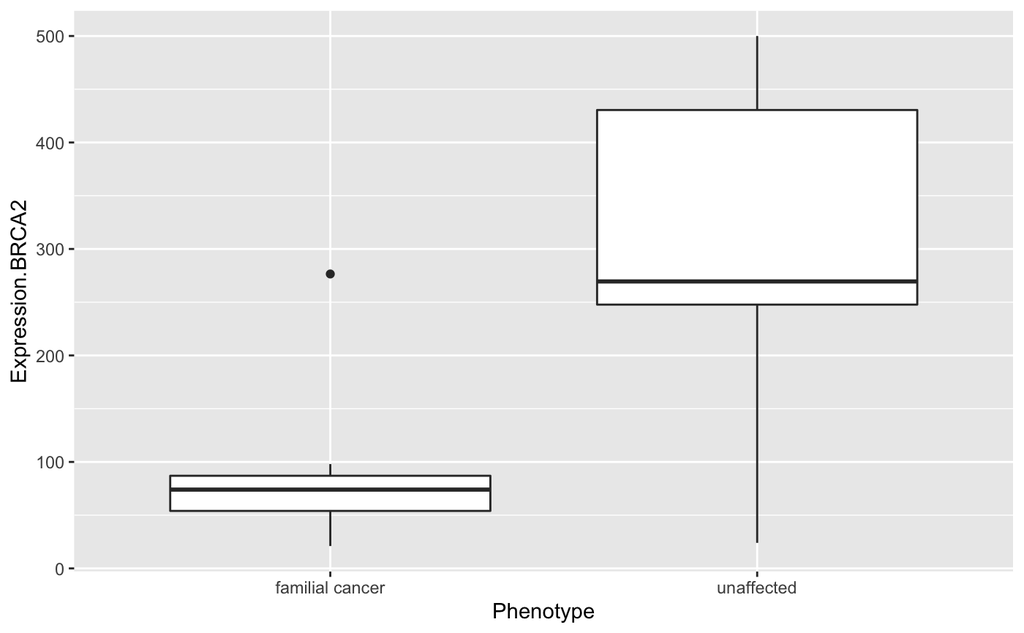

```r
ggplot(train.data)+
  geom_boxplot(aes(Phenotype, Expression.BRCA2))
```

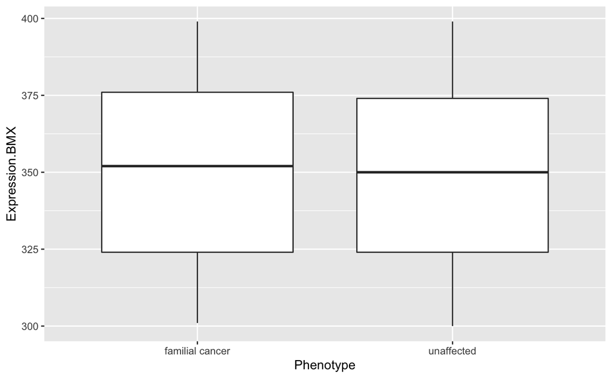

```r
ggplot(train.data)+
  geom_boxplot(aes(Phenotype, Expression.BMX))
```

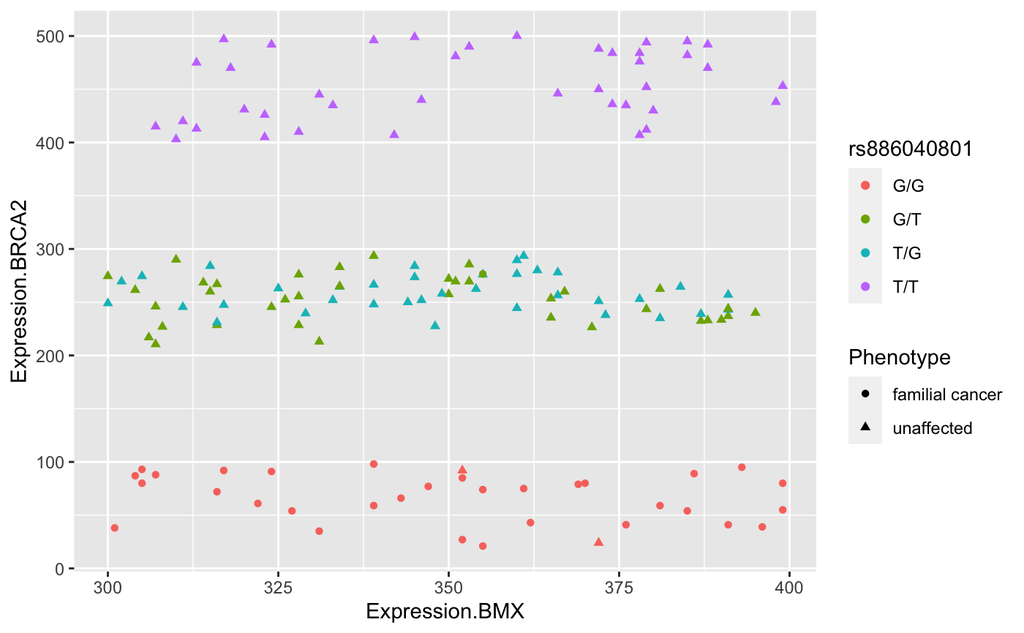

```r
ggplot(train.data, aes(x=Expression.BMX, y=Expression.BRCA2, color=rs886040801, shape=Phenotype))+
  geom_point()
```

## Support Vector Machine(SVM)

```r
cancer.svm <- svm(Phenotype ~  ., data = train.data )
table(train.data$Phenotype, predict(cancer.svm, train.data, type='prob'))
```

```
                  familial cancer unaffected
  familial cancer              32          1
  unaffected                    2        113
```

## Neural Network

The neural network requires our response variable be numerical so I have converted the ‘Phenotype’ column to 1/0 instead of Familial Cancer/unaffected.

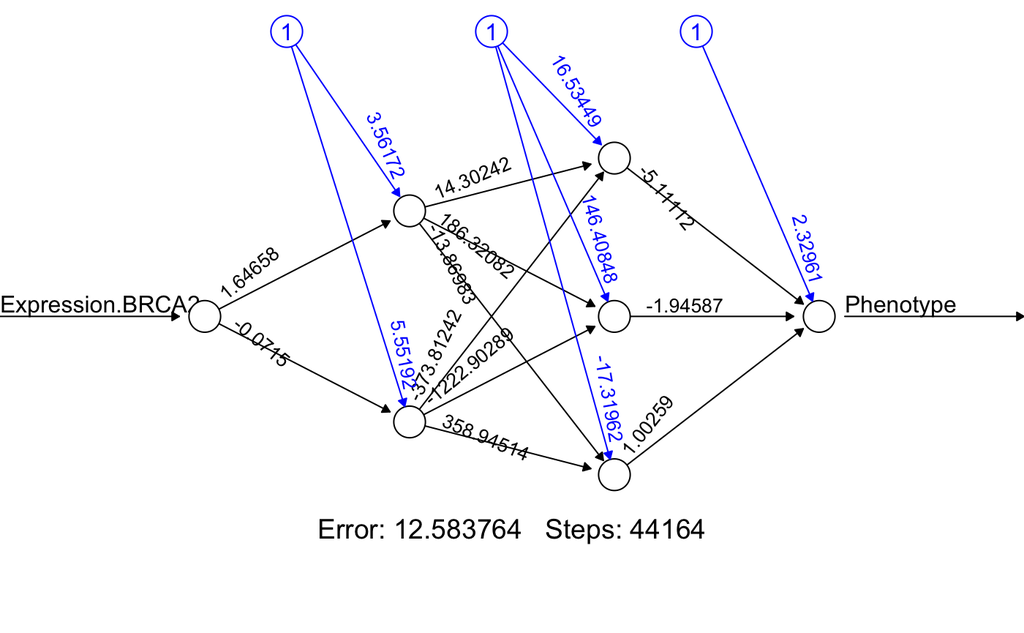

```r
train.logical <-train.data %>% mutate(Phenotype = ifelse(Phenotype == 'familial cancer', 1,0))


net<-neuralnet(Phenotype~Expression.BRCA2, train.logical
               ,hidden=c(2,3), err.fct="ce", linear.output=FALSE, rep = 2)

plot(net, rep="best")
```

```r
Predict <- neuralnet::compute(net, train.logical)
table(train.logical$Phenotype, round(Predict$net.result, 0))
```

```
      0   1
  0 113   2
  1   1  32
```

The neural net most offten only gets 3 miss-classification with the training data. This is a good result however this method required a bit more tailoring by changing the number of nodes and hidden layers in the model to get these results.

## random forest

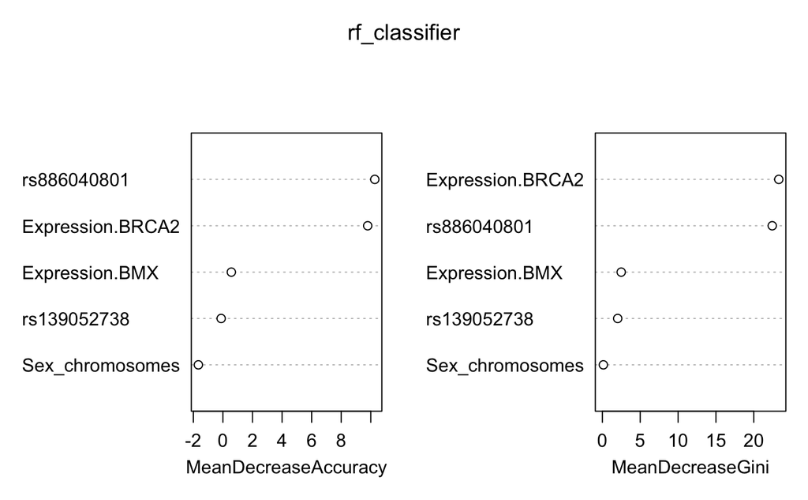

```r
rf_classifier = randomForest(Phenotype ~ Sex_chromosomes + rs139052738 + rs886040801 + Expression.BMX + Expression.BRCA2,
                             data=train.data, ntree=100, importance=TRUE)
varImpPlot(rf_classifier)
```

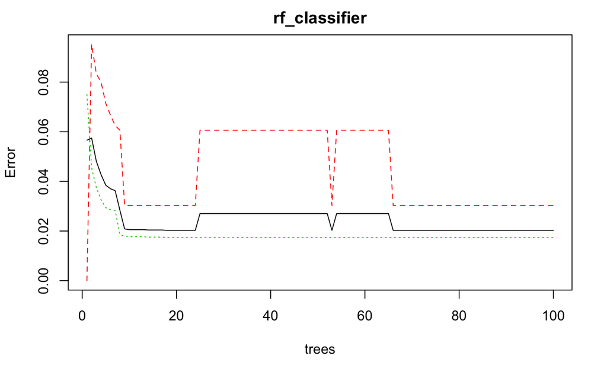

```r
plot(rf_classifier)
```

```r
table(train.data$Phenotype, predict(rf_classifier, train.data, type='class'))
```

```
                  familial cancer unaffected
  familial cancer              33          0
  unaffected                    0        115
```

The random forest method can get as low as 0 miss-classifications when trying to classify the training data, however, the benefit of using this method is that it takes comparatively less setup and can handle variables of various data types and weight their importance in classifying test data. This is why I have decided that this method has performed the best.

## Making a Prediction

```r
prediction_table <- predict(rf_classifier, predict.data, type = 'class')

data_frame(predict.data, prediction_table)
```

| Sex_chromosomes | rs139052738 | rs886040801 | Expression.BMX | Expression.BRCA2 | prediction_table |
| --- | --- | --- | --- | --- | --- |
| XX | C/C | G/T | 327 | 264 | unaffected |
| XX | T/T | T/G | 345 | 192 | unaffected |
| XX | T/C | G/G | 365 | 23 | familial cancer |
| XX | T/C | T/T | 376 | 435 | unaffected |
| XX | C/T | G/T | 335 | 270 | unaffected |
| XY | T | T/G | 372 | 251 | unaffected |
| XX | T/C | G/G | 324 | 42 | familial cancer |
| XX | C/T | G/G | 331 | 35 | familial cancer |

# Question B

The first of the two steps in our typical NGS pipeline that could be improved by machine learning is variant annotation and prioritisation and classification. This could be done in order to provide predictions of the variant pathogenicity or clinical relevance even for novel mutations by looking at contextual information such as the location of the variant, is it a splice site, is it frequently associated with disease along with any other data that could be used to predict variant classification.

This has been done before in the form of LEAP (Learning from Evidence to Assess Pathogenicity) which provides a web application to aid scientists in a clinical reporting workflow(Carmen, et al., 2020)

### References

Carmen, L., Anjali, D.Z., Robert, O., Serra, K., Ray, C., Jeroen, V.D.A, Alicia, Y.Z, Scott, T., and Gilad, M., 2020. LEAP: Using machine learning to support variant classification in a clinical setting. Human Mutation. [online] Available at: https://www.ncbi.nlm.nih.gov/pmc/articles/PMC7317941/